# Stat 420 Final Project - Modeling

Shashank Thakur, Net ID: sthakur5

27th July 2022

# Modeling California Housing Project Data Set

## Initialization

Read the data file to be used for this project.

```r
setwd("/Users/srthakur/Documents/GitHub/house_price_prediction/200_Final_Report")
ca_housing_data = read.csv('housing.csv')
# head(ca_housing_data)
```

Initialize global variables.

```r
# build different models to test the performance
n_models = 6
# create a vector list of models to pass to various functions
cahoudta_models = vector("list", length = n_models)
cahoudta_model_names = vector("character", length = n_models)
# Train-Test Split Ration
tr_pct = 0.50
```

## Helper Functions

**Function :** `model_performance_metrics` will generate model performance metrics such as RMSE and R-squared, etc.

**Inputs:**

*models :* A list of models to generate the performance metrics

*model_names :* Names of the models passed to the function

**Returns :** Returns a data frame with following performance metrics as columns and a row for each model provided in `model_names` as input.

```
              R2: R-Squared
              ADJR2: Adjusted R-Squared
              RMSE: Root Mean Square Error
              LOOCV_RMSE: Leave One Out Cross Validated RMSE
              Coefs: Total number of coefficients in the model
```

```r
model_performance_metrics = function(models, model_names){
  # Calculate model names and total numbers
  n_mod = length(models)
  # Initialize the data frame to be be built by the function
  perf_metrics_df = data.frame(
    row.names = model_names,
    "R2" = rep(0L, n_mod),
    "ADJR2" = rep(0L, n_mod),
    "RMSE" = rep(0L, n_mod),
    "LOOCV_RMSE" = rep(0L, n_mod),
    "Coefs" = rep(0L, n_mod)
  )

  for (idx in 1:n_mod){
    perf_metrics_df[model_names[idx], "R2"] = summary(models[[idx]])$r.squared
    perf_metrics_df[model_names[idx], "ADJR2"] = summary(models[[idx]])$adj.r.squared
    perf_metrics_df[model_names[idx], "RMSE"] = sqrt(mean(resid(models[[idx]]) ^ 2))
    perf_metrics_df[model_names[idx], "LOOCV_RMSE"] = sqrt(mean((resid(models[[idx]]) /
                                                                   (1 - hatvalues(models[[idx]]))) ^ 2))
    perf_metrics_df[model_names[idx], "Coefs"] = length(coef(models[[idx]]))
  }
  return(perf_metrics_df)
}
```

## Data cleaning

During initial data analysis phase, we determined that some of the columns have high multicollinearity and we decided to drop those columns. One example of such column is `total_bedrooms` which not only has multicollinearity with `total_rooms` but also has some missing data. We will drop this column to allow for modeling **response** variable `median_house_value`.

```r
ca_housing_data = subset(ca_housing_data, select = -total_bedrooms)
head(ca_housing_data)
```

```
##   longitude latitude housing_median_age total_rooms population households
## 1    -122.2    37.88                 41         880        322        126
## 2    -122.2    37.86                 21        7099       2401       1138
## 3    -122.2    37.85                 52        1467        496        177
## 4    -122.2    37.85                 52        1274        558        219
## 5    -122.2    37.85                 52        1627        565        259
## 6    -122.2    37.85                 52         919        413        193
##   median_income median_house_value ocean_proximity
## 1         8.325             452600        NEAR BAY
## 2         8.301             358500        NEAR BAY
## 3         7.257             352100        NEAR BAY
## 4         5.643             341300        NEAR BAY
## 5         3.846             342200        NEAR BAY
## 6         4.037             269700        NEAR BAY
```

We have another column `ocean_proximity` which is a categorical variable indicating how close the block is from ocean.

```r
table(ca_housing_data$ocean_proximity)
```

```
##
##  <1H OCEAN     INLAND     ISLAND   NEAR BAY NEAR OCEAN
##       9136       6551          5       2290       2658
```

As can be seen, this column has 5 different categories. The `ISLAND` category has only 5 observations. During initial analysis, our team determined that `ISLAND` has high leverage on the predicting response variable `median_house_value` which is problematic for our purpose. We will be dropping the rows from data set with `ISLAND` category and coercing the predictor `ocean_proximity` to be categorical.

```r
ca_housing_data = subset(ca_housing_data,
                         subset = ca_housing_data$ocean_proximity != "ISLAND")
table(ca_housing_data$ocean_proximity)
```

```
##
##  <1H OCEAN     INLAND   NEAR BAY NEAR OCEAN
##       9136       6551       2290       2658
```

```r
# Coerce ocean_proximity to a factor variable
ca_housing_data$ocean_proximity = as.factor(ca_housing_data$ocean_proximity)
is.factor(ca_housing_data$ocean_proximity)
```

```
## [1] TRUE
```

```r
levels(ca_housing_data$ocean_proximity)
```

```
## [1] "<1H OCEAN"  "INLAND"     "NEAR BAY"   "NEAR OCEAN"
```

## Model Building

```r
set.seed(420072022)
# Randomly select train indexes
cahoudta_trn_idx = sample(nrow(ca_housing_data),
                          size = trunc(tr_pct * nrow(ca_housing_data)))
# Split into train and test data sets based on the index
ca_housing_data.tr = ca_housing_data[cahoudta_trn_idx, ]
ca_housing_data.te = ca_housing_data[-cahoudta_trn_idx, ]

n_tr_rows = nrow(ca_housing_data.tr)
n_te_rows = nrow(ca_housing_data.te)
```

Next we will build models and start running tests.

```r
cahoudta_full_add_model = lm(log(median_house_value) ~ ., data = ca_housing_data.tr)
# summary(cahoudta_full_add_model)
```

Checking if there is multi-collinearity in the full fitted additive model. Following code snippet outputs all the predictors which has high variation inflation factors.

```r
high_vif_predictors = vif(cahoudta_full_add_model) > 5
high_vif_pred_vals = vif(cahoudta_full_add_model)[high_vif_predictors]
sort(high_vif_pred_vals)
```

```
##  population total_rooms  households   longitude    latitude
##       6.747      10.358      12.178      17.853      19.692
```

Based on variable inflation factors the predictors `households` and `latitude` can be dropped.

Lets try backward BIC search from the full additive model.

```r
cahoudta_add_bckwd_bic_model = step(cahoudta_full_add_model,
                                    direction = "backward",
                                    k = log(n_tr_rows),
                                    trace = 0)
```

Lets try two way interaction full additive model.

```r
cahoudta_2int_add_model = lm(log(median_house_value) ~ . ^ 2, data = ca_housing_data.tr)
```

Lets try backward BIC search from two way interaction full additive model.

```r
cahoudta_2int_bckwd_bic_model = step(cahoudta_2int_add_model,
                                    direction = "backward",
                                    k = log(n_tr_rows),
                                    trace = 0)
```

Lets drop the predictors `households` and `latitude` with high VIF.

```r
predictor_variables = colnames(ca_housing_data.tr)[-which(colnames(ca_housing_data.tr) == "median_house_value")]
drop_cols = which(colnames(ca_housing_data.tr) == "median_house_value" |
                    colnames(ca_housing_data.tr) == "households" |
                    colnames(ca_housing_data.tr) == "latitude")
smaller_predictors = colnames(ca_housing_data.tr)[-drop_cols]
less_preds = paste0("log(median_house_value) ~ ", paste(smaller_predictors, collapse = " + "))
cahoudta_lowvif_add_mod = lm(formula = less_preds, data = ca_housing_data.tr)
```

Lets add 2 way interaction for above model to check the performance.

```r
less_preds_2int = paste0("log(median_house_value) ~ (", paste(smaller_predictors, collapse = " + "), ") ^ 2")
cahoudta_lowvif_2int_mod = lm(formula = less_preds_2int, data = ca_housing_data.tr)
```

Test the performance metrics for the model(s).

```r
cahoudta_models[[1]] = cahoudta_full_add_model
cahoudta_model_names[[1]] = "cahoudta_full_add_model"

cahoudta_models[[2]] = cahoudta_add_bckwd_bic_model
cahoudta_model_names[[2]] = "cahoudta_add_bckwd_bic_model"

cahoudta_models[[3]] = cahoudta_2int_add_model
cahoudta_model_names[[3]] = "cahoudta_2int_add_model"

cahoudta_models[[4]] = cahoudta_2int_bckwd_bic_model
cahoudta_model_names[[4]] = "cahoudta_2int_bckwd_bic_model"

cahoudta_models[[5]] = cahoudta_lowvif_add_mod
cahoudta_model_names[[5]] = "cahoudta_lowvif_add_mod"

cahoudta_models[[6]] = cahoudta_lowvif_2int_mod
cahoudta_model_names[[6]] = "cahoudta_lowvif_2int_mod"

kable(model_performance_metrics(cahoudta_models, cahoudta_model_names),
      col.names = c("R-Squared",
                    "Adjusted R-Squared",
                    "RMSE",
                    "LOOCV RMSE",
                    "Coefficients"),
      caption = "Comparative Model Performance Metrics")
```

Comparative Model Performance Metrics

|  | R-Squared | Adjusted R-Squared | RMSE | LOOCV RMSE | Coefficients |
| --- | --- | --- | --- | --- | --- |
| cahoudta_full_add_model | 0.6650 | 0.6647 | 0.3302 | 0.3308 | 11 |
| cahoudta_add_bckwd_bic_model | 0.6647 | 0.6644 | 0.3303 | 0.3308 | 10 |
| cahoudta_2int_add_model | 0.7159 | 0.7144 | 0.3041 | 0.3098 | 53 |
| cahoudta_2int_bckwd_bic_model | 0.7147 | 0.7135 | 0.3047 | 0.3086 | 44 |
| cahoudta_lowvif_add_mod | 0.6292 | 0.6289 | 0.3474 | 0.3478 | 9 |
| cahoudta_lowvif_2int_mod | 0.6621 | 0.6610 | 0.3316 | 0.3332 | 34 |

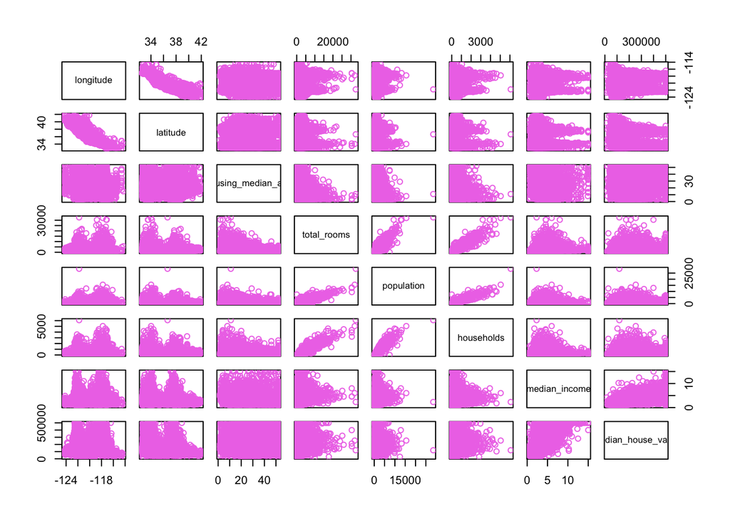

```r
pairs(subset(ca_housing_data.tr,
             select = -ocean_proximity),
      col = "orchid2")
```

## Model Selection

Work in progress…